# Regression og CAPM

Niels Richard Hansen

25. februar, 2021

Det dokument gennemgår analysen fra EH eksempel 11.13 i R. Dokumentet viser nogle R-tekniske løsninger, og kommentarerne omkring selve analysen er meget sparsomme, og skal ikke ses som fyldestgørende for hvordan en praktisk dataanalyse skal se ud.

Vi vil bruge diverse funktioner fra Tidyverse, så pakken indlæses først.

```r
library(tidyverse)
```

Vi indlæser data fra EH eksempel 11.13.

```r
CAPM <- read_csv("../Data/CAPM.csv")
```

Scatter plots af de tre variable mod hinanden.

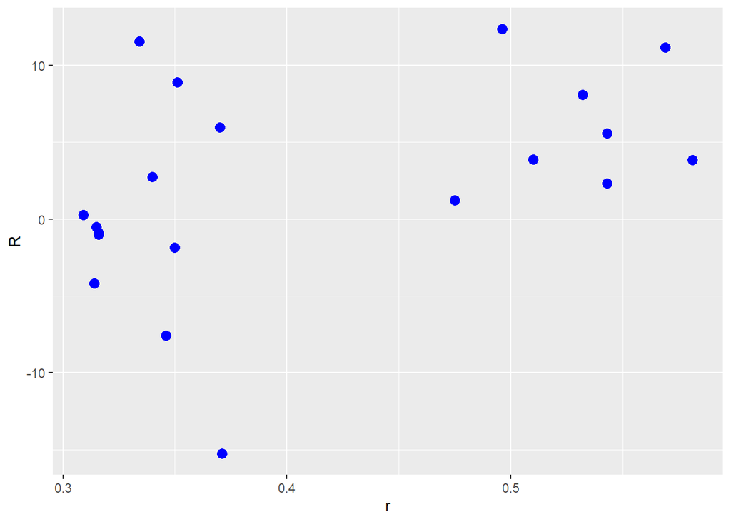

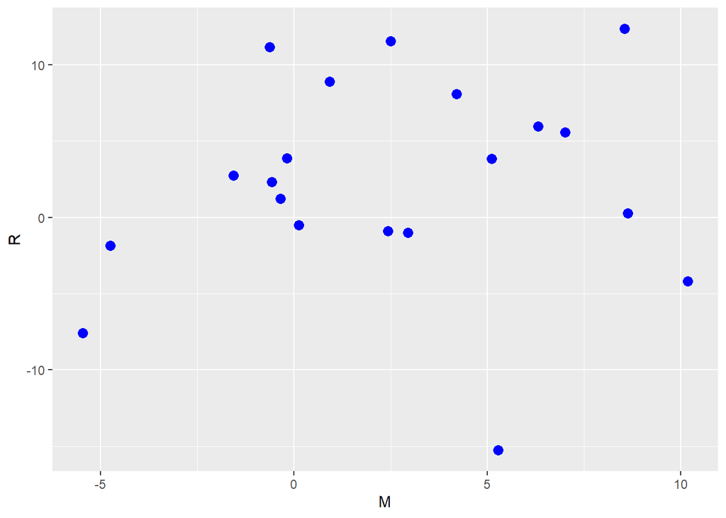

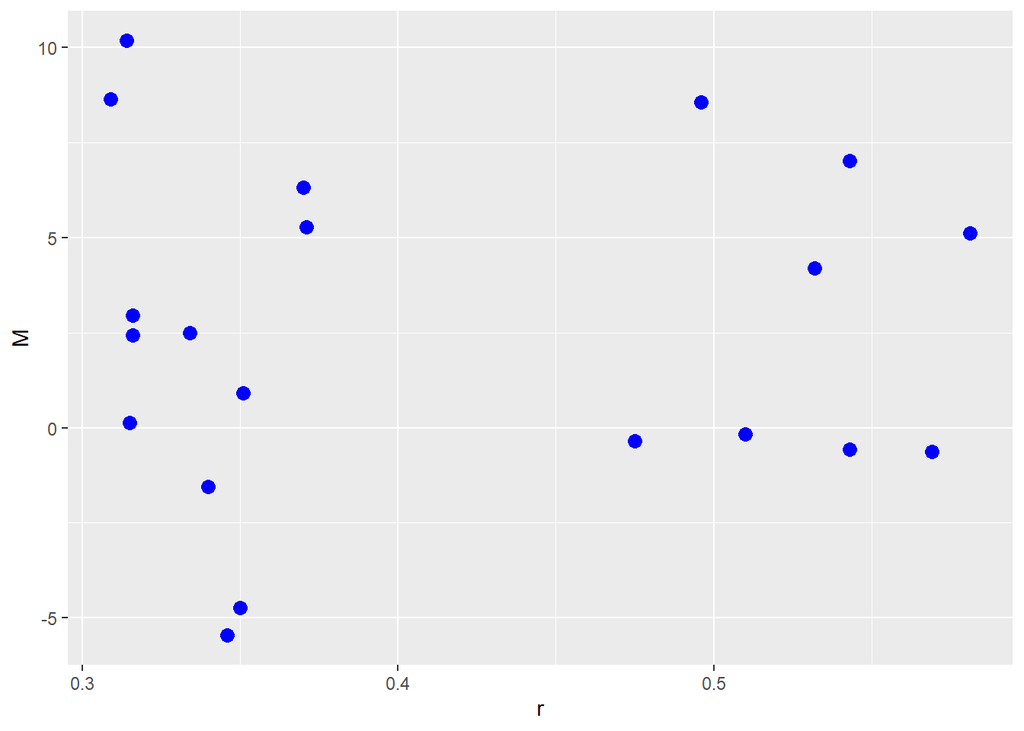

```r
qplot(r, R, data = CAPM, size = I(3), color = I("blue"))
qplot(M, R, data = CAPM, size = I(3), color = I("blue"))
qplot(r, M, data = CAPM, size = I(3), color = I("blue"))
```

Vi kan også plotte af de tre variable over tid, som giver god mening for det her datasæt.

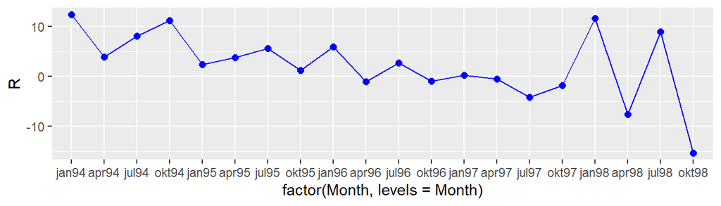

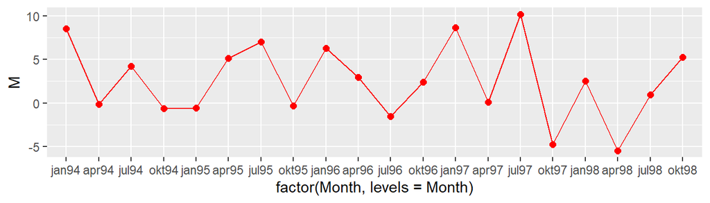

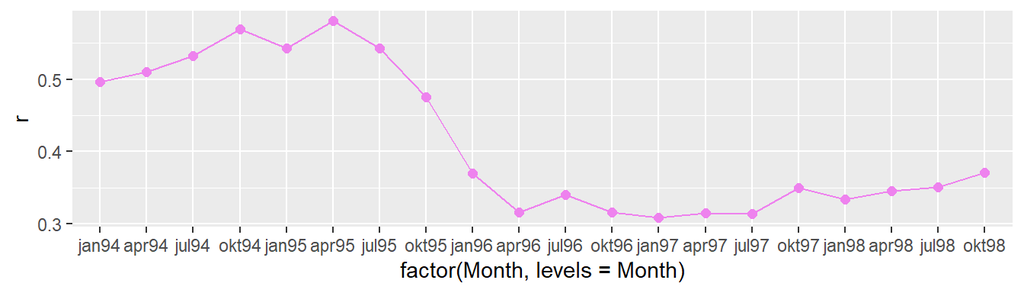

```r
qplot(factor(Month, levels = Month), R, data = CAPM, size = I(2), color = I("blue")) + geom_line(aes(group = 1), color = "blue")
qplot(factor(Month, levels = Month), M, data = CAPM, size = I(2), color = I("red")) + geom_line(aes(group = 1), color = "red")
qplot(factor(Month, levels = Month), r, data = CAPM, size = I(2), color = I("violet")) + geom_line(aes(group = 1), color = "violet")
```

# Regressionsmodellen

Vi genfinder nu den fittede model fra EH eksempel 11.13.

```r
CAPM_lm <- lm(R ~ M + r, data = CAPM)
summary(CAPM_lm)
```

```
##
## Call:
## lm(formula = R ~ M + r, data = CAPM)
##
## Residuals:
##      Min       1Q   Median       3Q      Max
## -16.7829  -2.6282  -0.4654   3.4771  11.5701
##
## Coefficients:
##             Estimate Std. Error t value Pr(>|t|)
## (Intercept) -10.0837     6.1645  -1.636   0.1203
## M             0.1556     0.3371   0.462   0.6502
## r            29.0208    14.4096   2.014   0.0601 .
## ---
## Signif. codes:  0 '***' 0.001 '**' 0.01 '*' 0.05 '.' 0.1 ' ' 1
##
## Residual standard error: 6.394 on 17 degrees of freedom
## Multiple R-squared:  0.2035, Adjusted R-squared:  0.1098
## F-statistic: 2.171 on 2 and 17 DF,  p-value: 0.1446
```

# Designmatricen

Vi kan konstruere designmatricen ved “håndkraft” fra data på følgende måde:

```r
A <- matrix(c(rep(1, 20), CAPM$M, CAPM$r), nrow = 20)
A
```

```
##       [,1]   [,2]  [,3]
##  [1,]    1  8.549 0.496
##  [2,]    1 -0.173 0.510
##  [3,]    1  4.199 0.532
##  [4,]    1 -0.630 0.569
##  [5,]    1 -0.565 0.543
##  [6,]    1  5.106 0.581
##  [7,]    1  7.012 0.543
##  [8,]    1 -0.346 0.475
##  [9,]    1  6.312 0.370
## [10,]    1  2.949 0.316
## [11,]    1 -1.556 0.340
## [12,]    1  2.432 0.316
## [13,]    1  8.631 0.309
## [14,]    1  0.123 0.315
## [15,]    1 10.174 0.314
## [16,]    1 -4.737 0.350
## [17,]    1  2.498 0.334
## [18,]    1 -5.460 0.346
## [19,]    1  0.921 0.351
## [20,]    1  5.283 0.371
```

Vi kan nu genfinde estimaterne ved løsning af et lineært ligningssystem.

```r
solve(t(A) %*% A, t(A) %*% CAPM$R)
```

```
##             [,1]
## [1,] -10.0837178
## [2,]   0.1555781
## [3,]  29.0207852
```

Designmatricen kan vi også trække ud af lm-objektet eller konstruere direkte med funktionen `model.matrix()`

```r
model.matrix(CAPM_lm)
```

```
##    (Intercept)      M     r
## 1            1  8.549 0.496
## 2            1 -0.173 0.510
## 3            1  4.199 0.532
## 4            1 -0.630 0.569
## 5            1 -0.565 0.543
## 6            1  5.106 0.581
## 7            1  7.012 0.543
## 8            1 -0.346 0.475
## 9            1  6.312 0.370
## 10           1  2.949 0.316
## 11           1 -1.556 0.340
## 12           1  2.432 0.316
## 13           1  8.631 0.309
## 14           1  0.123 0.315
## 15           1 10.174 0.314
## 16           1 -4.737 0.350
## 17           1  2.498 0.334
## 18           1 -5.460 0.346
## 19           1  0.921 0.351
## 20           1  5.283 0.371
## attr(,"assign")
## [1] 0 1 2
```

```r
model.matrix(~ M + r, data = CAPM)
```

```
##    (Intercept)      M     r
## 1            1  8.549 0.496
## 2            1 -0.173 0.510
## 3            1  4.199 0.532
## 4            1 -0.630 0.569
## 5            1 -0.565 0.543
## 6            1  5.106 0.581
## 7            1  7.012 0.543
## 8            1 -0.346 0.475
## 9            1  6.312 0.370
## 10           1  2.949 0.316
## 11           1 -1.556 0.340
## 12           1  2.432 0.316
## 13           1  8.631 0.309
## 14           1  0.123 0.315
## 15           1 10.174 0.314
## 16           1 -4.737 0.350
## 17           1  2.498 0.334
## 18           1 -5.460 0.346
## 19           1  0.921 0.351
## 20           1  5.283 0.371
## attr(,"assign")
## [1] 0 1 2
```

# Residualplot

Først plotter vi de rå residualer

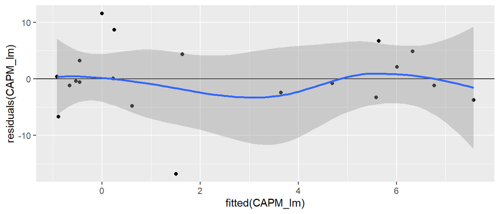

```r
qplot(fitted(CAPM_lm), residuals(CAPM_lm)) +
    geom_hline(yintercept = 0) +
    geom_smooth()
```

og dernæst residualerne standardiseret med det centrale estimat for spredningen.

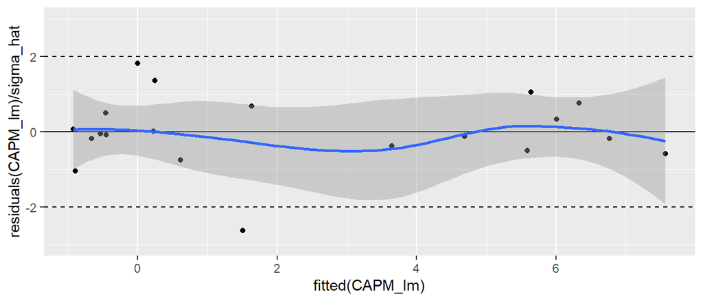

```r
sigma_hat <- sqrt(sum(residuals(CAPM_lm)^2) / 17)  # Centralt variansestimate
qplot(fitted(CAPM_lm), residuals(CAPM_lm) / sigma_hat) +
    geom_hline(yintercept = 0) +
    geom_hline(yintercept = -2, linetype = 2) +
    geom_hline(yintercept = 2, linetype = 2) +
    geom_smooth() +
    ylim(-3, 3)
```

Endelig plotter vi de standardiserede residualer (røde nedenfor), hvor der altså også er devideret med $\sqrt{1 - h_{ii}}$, sammenholdt med residualerne ovenfor.

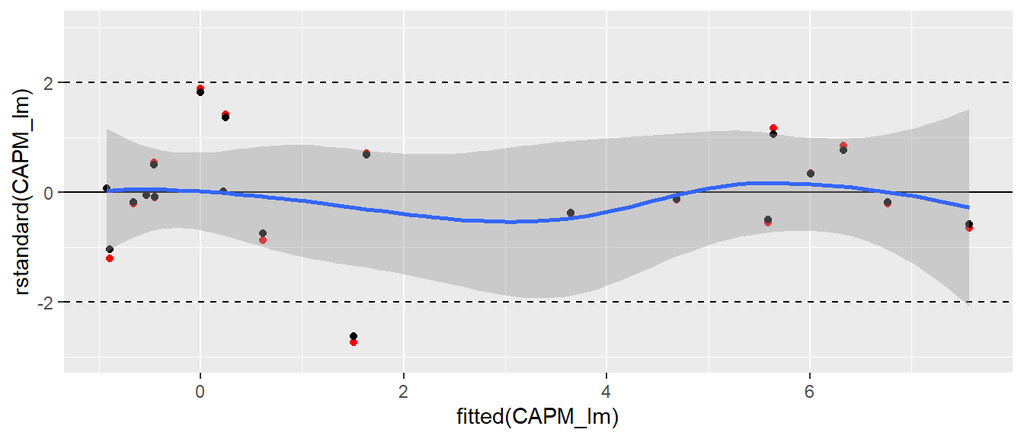

```r
qplot(fitted(CAPM_lm), rstandard(CAPM_lm), color = I("red")) +
    geom_point(aes(y = residuals(CAPM_lm) / sigma_hat)) +
    geom_hline(yintercept = 0) +
    geom_hline(yintercept = -2, linetype = 2) +
    geom_hline(yintercept = 2, linetype = 2) +
    geom_smooth() +
    ylim(-3, 3)
```

Man kan observere, at effekten af division med $\sqrt{1 - h_{ii}}$ er ganske lille, men alle observationerne flytter udad. Vi kan udtrække $h_{ii}$ fra lm-objektet med `hatvalues()`, hvis vi vil.

```r
range(1 / sqrt(1 - hatvalues(CAPM_lm)))
```

```
## [1] 1.040627 1.170057
```

For det her eksempel er det også værd at se på residualerne som funktion af tid, og lave et lag-plot for at se, om der er afhængighed.

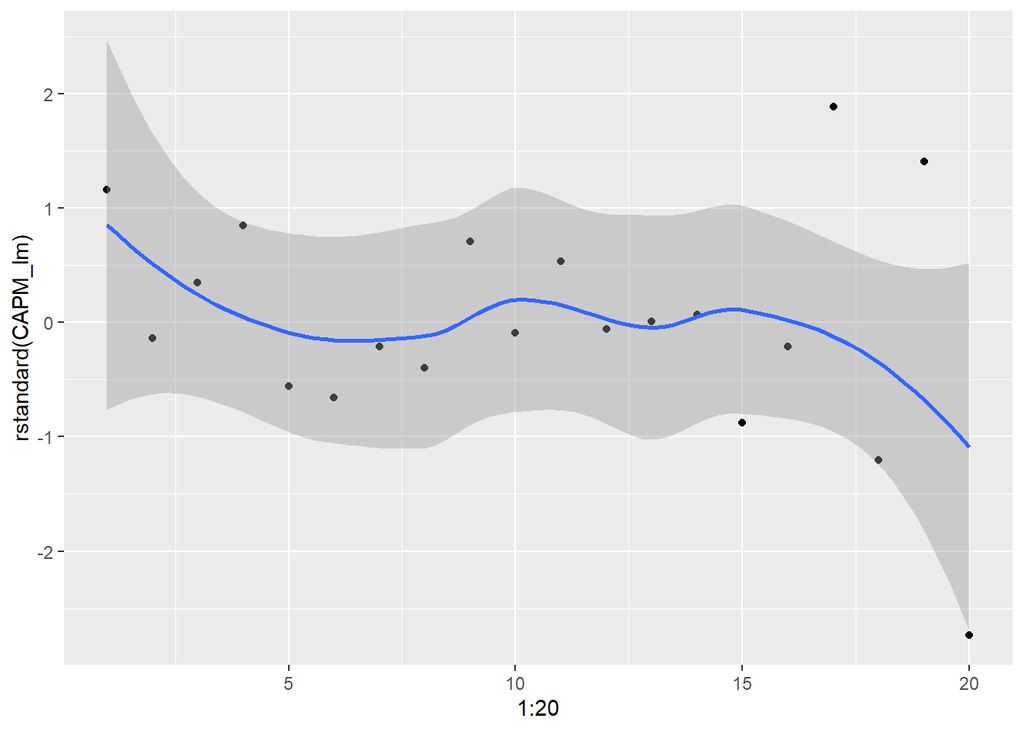

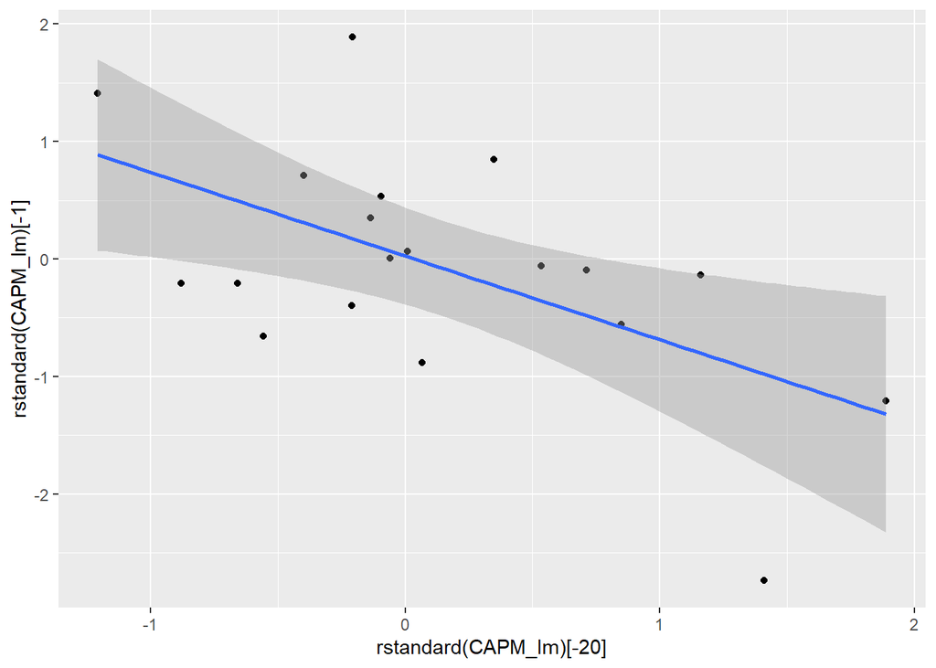

```r
qplot(1:20, rstandard(CAPM_lm)) +
    geom_smooth()
qplot(rstandard(CAPM_lm)[-20], rstandard(CAPM_lm)[-1]) +
    geom_smooth(method = "lm")
```

Lag-plottet indikerer, at fejlene er negativt korrelerede.

Vi kan også lave et QQ-plot for at undersøge normalfordelingsantagelsen. Med kun 20 observationer er det ganske svært at afvise normalfordelingen.

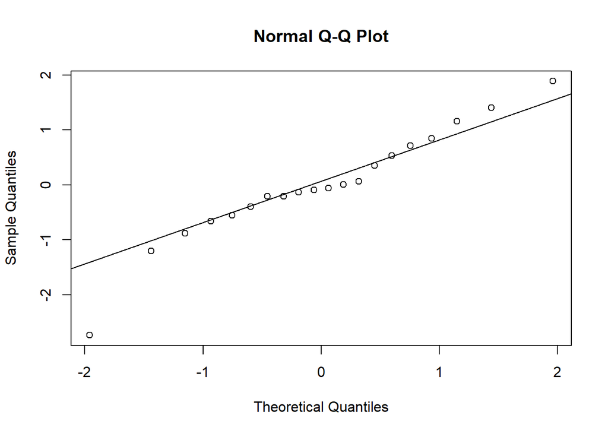

```r
qqnorm(rstandard(CAPM_lm))
qqline(rstandard(CAPM_lm))
```

## Konfidensintervaller

Vi kan til slut genfinde konfidensintervallerne fra EH ved at bruge `confint()` på lm-objektet. Den omsætter estimater og standard errors til standard konfidensintervaller baseret på den korrekte $t$-fordeling.

```r
confint(CAPM_lm)
```

```
##                   2.5 %     97.5 %
## (Intercept) -23.0895931  2.9221576
## M            -0.5555732  0.8667294
## r            -1.3808162 59.4223867
```

Reducerer vi modellen ved at fjerne interceptet fås et noget anderledes estimat, og en reduktion i standard errors for $\hat{\gamma}$. Det skyldes primært at $r$ varierer ganske lidt og interceptsøjlen og $r$ kommer til at være tæt på hinanden. Om de ligefrem er tæt på at være kollineære er til diskussion.

```r
CAPM_lm_0 <- lm(R ~ M + r - 1, data = CAPM)
summary(CAPM_lm_0)
```

```
##
## Call:
## lm(formula = R ~ M + r - 1, data = CAPM)
##
## Residuals:
##      Min       1Q   Median       3Q      Max
## -18.1457  -3.1795  -0.7022   3.3169   9.2088
##
## Coefficients:
##   Estimate Std. Error t value Pr(>|t|)
## M  0.09853    0.35052   0.281    0.782
## r  6.32644    4.07043   1.554    0.138
##
## Residual standard error: 6.685 on 18 degrees of freedom
## Multiple R-squared:  0.1799, Adjusted R-squared:  0.08875
## F-statistic: 1.974 on 2 and 18 DF,  p-value: 0.1678
```

```r
confint(CAPM_lm_0)
```

```
##        2.5 %     97.5 %
## M -0.6378792  0.8349428
## r -2.2252161 14.8780969
```